# DS4P: Probability and Probability Distributions

DS4P: Probability and Probability Distributions Week 8

## Learning Objectives

1. Understand fundamental concepts of probability and how they apply to data analysis
2. Distinguish between discrete and continuous probability distributions
3. Master the normal distribution and its properties
4. Calculate and interpret z-scores and their relationship to standard deviations
5. Use R functions (`pnorm`, `qnorm`, `dnorm`) to calculate probabilities and quantiles
6. Apply the empirical rule to normal distributions

## What Is This For?

So far in this course, we’ve learned to describe data - calculating means, creating visualizations, measuring spread. But description is only the beginning. The real power of statistics comes from making inferences: using what we observe in our sample to make claims about the broader population.

To make that leap from description to inference, we need to understand **uncertainty**. When a poll reports that 52% of voters support a candidate “with a margin of error of ±3%,” that margin comes from probability theory. When researchers claim their results are “statistically significant,” they’re making a probability statement. When a forecaster says a candidate has a 70% chance of winning, they’re using probability distributions.

This session introduces the foundation that makes all of this possible – probability. We’ll start with simple probability, build up to the normal distribution (the most important distribution in statistics), and learn how to calculate probabilities in R.

This only touches on the subject, and I will focus on concepts over formal definitions or mathematics. But having some intuition about probability will help you understand concepts later in the class. And you will certainly need to know how to calculate probabilities in R.

## Part I: Foundations of Probability

### What is Probability?

At its core, **probability** is the relative frequency of occurrence for some outcome if a process is repeated many times under similar conditions. It’s a number between 0 (impossible) and 1 (certain) that quantifies how likely something is to happen. And if you consider all of the possibe events that could happen, the total probability should sum to 1.

Let’s start with a concrete example that builds intuition: rolling two dice.

#### Example: Two Dice

When you roll two six-sided dice, there are 36 possible outcomes:

| Die 1 → | **1** | **2** | **3** | **4** | **5** | **6** |
| --- | --- | --- | --- | --- | --- | --- |
| **1** | (1,1) | (1,2) | (1,3) | (1,4) | (1,5) | (1,6) |
| **2** | (2,1) | (2,2) | (2,3) | (2,4) | (2,5) | (2,6) |
| **3** | (3,1) | (3,2) | (3,3) | (3,4) | (3,5) | (3,6) |
| **4** | (4,1) | (4,2) | (4,3) | (4,4) | (4,5) | (4,6) |
| **5** | (5,1) | (5,2) | (5,3) | (5,4) | (5,5) | (5,6) |
| **6** | (6,1) | (6,2) | (6,3) | (6,4) | (6,5) | (6,6) |

To find the probability of any sum, we count how many ways we can get that sum and divide by 36.

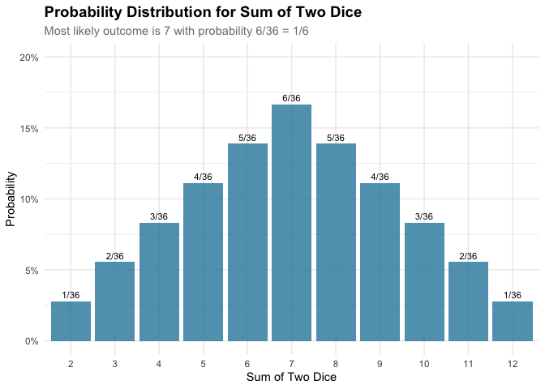

For example, there is only one way to end up with two dice that sum to two. So the probability of two is 1/36. Meanwhile, there are 6 ways to end up with a seven, so the probability of seven is 6/36. We can do that for all possible numbers.

This bar chart shows a **discrete probability distribution** - each possible outcome has a specific probability, and all probabilities sum to 1. The outcome (the sum of two die) is on the x-axis. The probability that even twill occur is on the y-axis.

### Discrete vs. Continuous Distributions

**Discrete distributions** deal with countable outcomes:

- Number of yes votes in the Senate (0, 1, 2, …, 100)
- Number of supreme court justices appointed by a president
- Survey responses on a 1-5 scale

**Continuous distributions** deal with measurements that can take any value in a range:

- Voter approval ratings (any percentage from 0% to 100%)
- Campaign spending (any dollar amount)
- Time until election results are called

With continuous distributions, we don’t ask “What’s the probability of exactly 51.7%?”. Since there are infinitely many outcomes, the probability of any specific number is actually 0! Instead, we ask about ranges: “What’s the probability of getting between 51% and 52%?”

### Formal Properties of Probability Distributions

Now that we have intuition about probability, let’s formalize these concepts. Understanding these properties helps us verify that our calculations are correct and builds the foundation for statistical inference.

#### Properties of Discrete Probability Distributions

For discrete random variables (like the sum of two dice or number of Senate votes), we use a **probability mass function (PMF)** to assign probabilities to each possible outcome.

**Formal Definition**: If X is a discrete random variable that can take values x₁, x₂, x₃, …, then P(X = xᵢ) gives the probability of each outcome.

**Two fundamental properties must always hold:**

1. **Non-negativity**: Every probability must be between 0 and 1
   $$0 \leq P(X = x_i) \leq 1
   \text{ for all } i$$
2. **Probabilities sum to 1**: The total probability across all possible outcomes equals 1
   $$\sum_{i} P(X = x_i) = 1$$

Let’s verify these properties with our dice example:

```r
# Verify the formal properties for our dice distribution
dice_probs <- data.frame(
  sum = 2:12,
  ways = c(1, 2, 3, 4, 5, 6, 5, 4, 3, 2, 1),
  probability = c(1, 2, 3, 4, 5, 6, 5, 4, 3, 2, 1) / 36
)

# Property 1: All probabilities between 0 and 1?
all(dice_probs$probability >= 0 & dice_probs$probability <= 1)
```

```
## [1] TRUE
```

```r
# Property 2: Do probabilities sum to 1?
sum(dice_probs$probability)
```

```
## [1] 1
```

#### Properties of Continuous Probability Distributions

For continuous random variables (like approval ratings or voter turnout), we use a **probability density function (PDF)** denoted as f(x).

**Key insight**: For continuous distributions, the probability of any exact value is 0. Instead, probabilities are “areas under the curve.”

**Formal Definition**: If X is a continuous random variable with PDF f(x), then: - f(x) gives the **density** at point x (height of the curve) - P(a < X < b) = area under f(x) between a and b

**Two fundamental properties must always hold:**

1. **Non-negativity**: The density function must be non-negative everywhere
   $$f(x) \geq 0 \text{
   for all } x$$
2. **Total area equals 1**: The total area under the curve equals 1
   $$\int_{-\infty}^{\infty} f(x)
   \, dx = 1$$

If that integration symbol seems intimidating, don’t worry about it. We will never be doing these calculations by hand. Instead, we will let R handle these calculations for us. The key points to undersand are that:

- Probability for any range of values is the “area under the curve”
- The total probability “under the curve” for all possible values must sum to 1.

### Parameters of Distributions

Every probability distribution has characteristics that summarize its behavior. The two most important are:

1. **Mean (μ, “mu”)**: The expected value or long-run average
2. **Variance (σ², “sigma squared”)**: How spread out the values are

**Critical Distinction: Parameters vs. Statistics**

This is one of the most important conceptual distinctions in statistics, and it’s easy to confuse. Let’s break it down:

**Population Parameters** (Greek letters)

- These are the TRUE values for the entire population
- We almost never know these values
- They are fixed, unchanging numbers
- We use Greek letters to denote them:
  - **μ** (mu) = true population mean
  - **σ²** (sigma squared) = true population variance
  - **σ** (sigma) = true population standard deviation

**Sample Statistics** (Roman letters)

- These are what we CALCULATE from our data
- They vary from sample to sample
- They are our best guesses at the population parameters
- We use Roman letters with special notation:
  - **x̄** (x-bar) = sample mean
  - **s²** = sample variance
  - **s** = sample standard deviation

**Why This Matters: An Example**

Imagine we want to know the average age of all U.S. voters (about 240 million people):

- **μ** = the TRUE average age of all 240 million voters (maybe 47.3 years)
  - This is unknown unless we survey everyone (census)
  - It’s a fixed number that exists in reality
- **x̄** = the average age from our sample of 1,000 voters (maybe 46.8 years)
  - This is what we actually calculate
  - If we took a different sample, we’d get a different x̄ (maybe 47.9)
  - We hope it’s close to μ, but it’s not exactly μ

The entire field of statistical inference is about using what we can calculate (statistics like x̄) to make educated guesses about what we want to know (parameters like μ). This is why we need probability theory - to understand how much our sample statistics might vary from the true population parameters.

## Part II: The Normal Distribution

### Properties and Importance

The **normal distribution** (also called the Gaussian distribution or bell curve) is the most important probability distribution in statistics. It appears everywhere because of the Central Limit Theorem, which says that sample averages (means) tend to follow a normal distribution regardless of the original data’s shape.

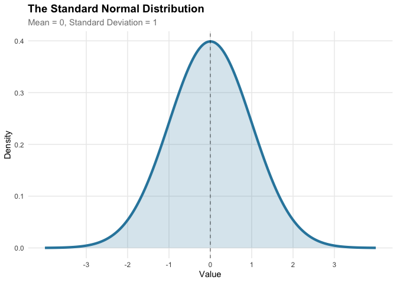

**Key properties of the normal distribution:**

1. **Bell-shaped** and perfectly **symmetric** around the mean
2. **Mean = Median = Mode** (all at the center)
3. Completely determined by two parameters: μ (mean) and σ (standard deviation)
4. Total area under the curve = 1 (like all probability distributions)
5. Tails technically extend infinitely but get very close to zero for values far from the mean

### The Standard Normal and Z-Scores

The **standard normal distribution** is a special case where μ = 0 and σ = 1. Any normal distribution can be converted to standard normal using:

$$Z = \frac{X - \mu}{\sigma}$$

This transformation is called **standardization**, and the result is a **z-score**.

#### What Z-Scores Tell Us

A z-score tells you how many standard deviations a value is from the mean:

- Z = 0: exactly at the mean
- Z = 1: one standard deviation above the mean
- Z = -2: two standard deviations below the mean

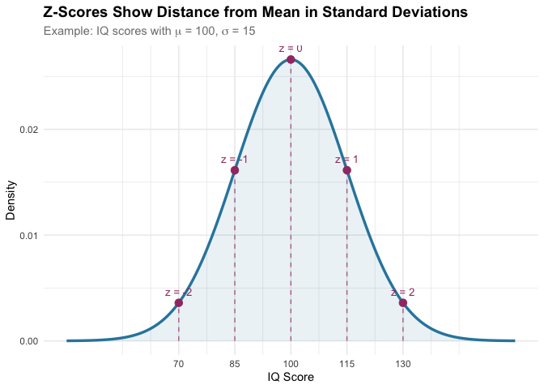

### The Empirical Rule (68-95-99.7)

For any normal distribution:

- **~68%** of values fall within ±1σ of the mean
- **~95%** of values fall within ±2σ of the mean
- **~99.7%** of values fall within ±3σ of the mean

This rule provides quick probability estimates without calculation. For example, if test scores are normally distributed with μ = 75 and σ = 10:

- About 68% score between 65 and 85
- About 95% score between 55 and 95
- Scores below 45 or above 105 are very rare (~0.3%)

## Part III: Working with Probability in R

### Key R Functions for the Normal Distribution

R provides four essential functions for working with normal distributions:

| Function | Purpose | What It Returns | Example |
| --- | --- | --- | --- |
| `dnorm(x)` | **Density** | Height of the curve at point x | `dnorm(0)` = 0.399 |
| `pnorm(x)` | **Probability** | Area to the left of x (cumulative probability) | `pnorm(0)` = 0.5 |
| `qnorm(p)` | **Quantile** | The x value with p area to its left | `qnorm(0.5)` = 0 |
| `rnorm(n)` | **Random** | n random values from the distribution | `rnorm(100)` generates 100 values |

Think of these as answering different questions:

- `dnorm`: “How tall is the curve here?”
- `pnorm`: “What’s the probability of getting less than x?”
- `qnorm`: “What value of x has probability p below it?”
- `rnorm`: “Give me random data from this distribution”

### Calculating Probabilities with pnorm()

The `pnorm()` function calculates cumulative probabilities - the area under the curve to the left of a value. Think of it as answering: **“What percentage of the population falls below this value?”** It is what is called the **cumulative density function** for the normal distribution.

**Intuitive Analogy**: Imagine lining up everyone in order by height. `pnorm()` tells you what percentage of people you’d have to walk past before reaching someone of a specific height.

```r
# Example: Test scores in a class are normally distributed
# The mean score is 45 with a standard deviation of 5
mu <- 45      # Population mean atest score
sigma <- 5    # Population standard deviation
threshold <- 50  # We want to know: what % of students scored 50 or less

# pnorm calculates the cumulative probability (area to the left)
# It answers: "What proportion of students scored below 40?"
prob <- pnorm(threshold, mean = mu, sd = sigma)
print(prob)
```

```
## [1] 0.8413447
```

This means about 84.1% of students scored below 50%, only 15.9% scored above 50%.

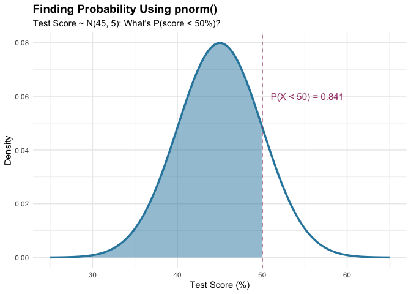

**Key Points about `pnorm()`**:

- Always gives a number between 0 and 1
- `pnorm(mean)` always equals 0.5 (half below, half above)
- Larger values → probabilities closer to 1
- Smaller values → probabilities closer to 0

For probabilities to the right, use `lower.tail = FALSE`:

```r
# Sometimes we want P(X > some value) instead of P(X < some value)
# Use lower.tail = FALSE to get the area to the RIGHT

# What's the probability someone scores MORE than 50%?
prob_right <- pnorm(50, mean = 45, sd = 5, lower.tail = FALSE)
print(prob_right)
```

```
## [1] 0.1586553
```

```r
# Notice: prob + prob_right = 1.000 (they're complements!)
```

We can also calculate the probability of an interval. We do this by subtracting. For example, what if we wanted to know what percent of people scored between 40 and 50. We can calculate the first the probability that people scored below 50%. Then we calculate the probability that they scored below 40. When we subtract these two, we get the probability that they fall in the middle.

```r
# For intervals, we need to subtract two probabilities
# Example: What % of people have approval between 40% and 50%?
prob_below_50 <- pnorm(50, mean = 45, sd = 5)  # P(X < 50)
prob_below_40 <- pnorm(40, mean = 45, sd = 5)  # P(X < 40)
prob_interval <- prob_below_50 - prob_below_40  # P(40 < X < 50)
print(round(prob_interval, 3))
```

```
## [1] 0.683
```

The probability is about 68.3%.

**Visualization**: To see this visually, think about what `pnorm` calculates when we put in 50 and what it looks like when we put in 40. When we subtract one from the other, we get the interval in between.

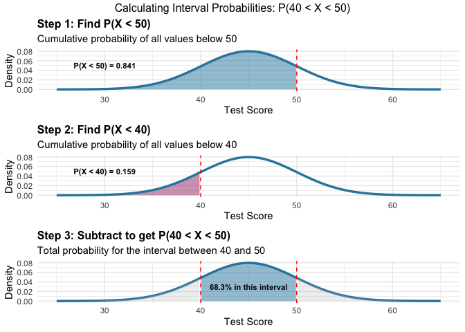

### Finding Quantiles with qnorm() - The Inverse Problem

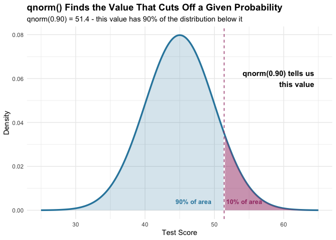

The `qnorm()` function is the **inverse** of `pnorm()`. It is something called a **quantile function** for the normal distribution. This confuses many students, so let’s break it down:

**pnorm() asks**: “Given a value, what’s the probability below it?”

**qnorm() asks**: “Given a probability, what value has that much below it?”

**Think of it like this:**

- `pnorm()` is like asking: “If someone is 6 feet tall, what percentile are they?”
- `qnorm()` is like asking: “What height represents the 90th percentile?”

**Another way to think about it:**

- `pnorm()`: Value → Probability (forward direction)
- `qnorm()`: Probability → Value (reverse direction)

Let’s see how `pnorm` and `qnorm` are inverses of each other

```r
mu <- 45      # Test scores with  mean 45
sigma <- 5    # and standard deviation 5

# Start with a specific test value
original_value <- 48  # Someone with score of 48

# Step 1: Use pnorm to find what percentile this person is at
# "What percentage of people have score of 48 or below?"
prob <- pnorm(original_value, mean = mu, sd = sigma)
print(prob)
```

```
## [1] 0.7257469
```

We can see that about 72.6% of students scored below 48.

We use `qnorm` to convert back from percentile to score. We ask, “What score corresponds to the 72.6th percentile?”

```r
back_to_value <- qnorm(prob, mean = mu, sd = sigma)
print(back_to_value)
```

```
## [1] 48
```

They’re inverses - we get back where we started!

**Common qnorm() Applications:**

There are three common ways we use `qnorm`.

1. We use it to find specific percentils?
2. We use it to find important “cutoffs.”
3. We use it to find important middle ranges.

**Finding specific quantiles**

Let’s go back to our test example. What is the 75th percentile for this test? That is, what score would you need to have to score aboe 75% of other students?

```r
percentile_75 <- qnorm(0.75, mean = mu, sd = sigma)
print(percentile_75)
```

```
## [1] 48.37245
```

**Finding “cutoffs”**

I can use this same idea to find important cutoffs at both the top and the bottom of the distribution. For instance, let’s say that I want to find all of the students in the class in the top 10%. I just need to find the “cutoff” that divides the top 10% from the bottom 90%. Since `pnorm` by default calculates probabilities *below* a quantile we can just do:

```r
top_10_cutoff <- qnorm(0.90, mean = mu, sd = sigma)
print(round(top_10_cutoff, 2))
```

```
## [1] 51.41
```

Now I would just look for any student who scored higher than this threshold!

**Finding symmetric intervals**

Sometimes we might want to find symmetric intervals around the mean that include a certain percentage of the distribution. For instance, we might ask, “What range contains the middle 90% of scores?” Using the same ideas as before, we just calculate the following.

```r
# Middle 90% means 5% in each tail, so 5th and 95th percentiles
lower_5 <- qnorm(0.05, mean = mu, sd = sigma)  # 5th percentile
upper_95 <- qnorm(0.95, mean = mu, sd = sigma)  # 95th percentile
print(paste0("Middle 90% of scores: ", round(lower_5, 1), " to ", round(upper_95, 1)))
```

```
## [1] "Middle 90% of scores: 36.8 to 53.2"
```

### Understanding dnorm(): The Height of the Curve

While `pnorm()` gives us probabilities (areas), `dnorm()` is the **density function** - the height of the normal curve at any point. This doesn’t directly give us a probability, but it’s useful for:

- Drawing normal distributions
- Understanding where the curve is tallest (at the mean)

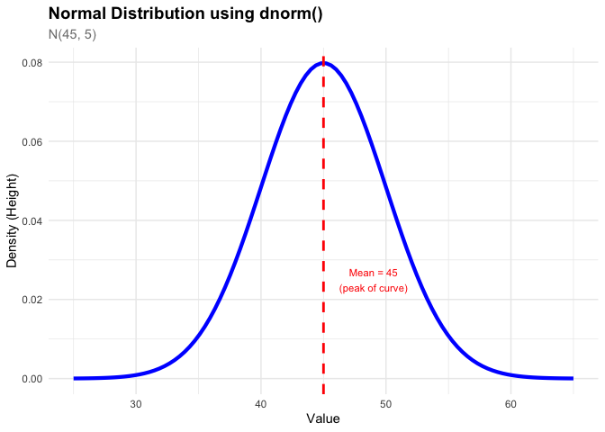

```r
# Simple example: Plot a normal distribution with mean=45, sd=5
mu <- 45
sigma <- 5

# Step 1: Create a sequence of x values
# We need points along the x-axis where we'll calculate the height
x <- seq(from = mu - 4*sigma,   # Start at 4 SDs below mean (40)
         to = mu + 4*sigma,      # End at 4 SDs above mean (160)
         length.out = 100)       # Use 100 points for smooth curve

# Step 2: Calculate the height (density) at each x value using dnorm()
y <- dnorm(x, mean = mu, sd = sigma)

# Step 3: Create a data frame for ggplot
df <- data.frame(x = x, y = y)

# Step 4: Plot the normal distribution
ggplot(df, aes(x = x, y = y)) +
  geom_line(color = "blue", size = 1.5) +  # Draw the curve
  geom_vline(xintercept = mu,              # Add vertical line at mean
             color = "red",
             linetype = "dashed",
             size = 1) +
  annotate("text",                         # Add text annotation
           x = mu + 4,
           y = 0.025,
           label = "Mean = 45\n(peak of curve)",
           color = "red",
           size = 3) +
  labs(
    title = "Normal Distribution using dnorm()",
    subtitle = "N(45, 5)",
    x = "Value",
    y = "Density (Height)"
  ) +
  theme_minimal() +
  theme(
    plot.title = element_text(size = 14, face = "bold"),
    plot.subtitle = element_text(size = 11, color = "gray50")
  )
```

The `dnorm()` function calculates the **probability density function** (PDF) of the normal distribution:

$$f(x) = \frac{1}{\sigma\sqrt{2\pi}}
e^{-\frac{1}{2}\left(\frac{x-\mu}{\sigma}\right)^2}$$

Where:

- $x$ is the value where you want the height
- $\mu$ is the mean
- $\sigma$ is the standard deviation
- $e \approx 2.718$ is Euler’s number
- $\pi \approx 3.14159$

This formula gives the height of the bell curve at any point $x$. But you will never have to use this formula, because R will do it for you (or I will just give you the R output you need).

### Generating Random Data with rnorm()

The `rnorm()` function generates random values from a normal distribution. This is incredibly useful for:

- Simulations
- Testing code before you have real data
- Understanding sampling variability
- Bootstrap methods (advanced topic)

```r
# rnorm() generates random values from a normal distribution
# Syntax: rnorm(n, mean, sd) where n is how many values you want

# IMPORTANT: Set seed for reproducibility
# Without set.seed(), you get different random numbers each time
set.seed(123)  # Any number works - this ensures we all get the same "random" results

# Generate 1000 random test scores from N(45, 5)
n_people <- 1000
mu<-45    # True population mean
sigma<-5  # True population standard deviation

# Generate the random sample
random_scores <- rnorm(n = n_people, mean = mu, sd = sigma)
print(random_scores[1:20]) # print first 20 randomly selected values
```

```
##  [1] 42.19762 43.84911 52.79354 45.35254 45.64644 53.57532 47.30458 38.67469
##  [9] 41.56574 42.77169 51.12041 46.79907 47.00386 45.55341 42.22079 53.93457
## [17] 47.48925 35.16691 48.50678 42.63604
```

## Part IV: Looking Ahead

### The t-Distribution: When Samples Are Small

While the normal distribution is fundamental, real-world data analysis often involves small samples where we don’t know the population standard deviation. Enter the **t-distribution**:

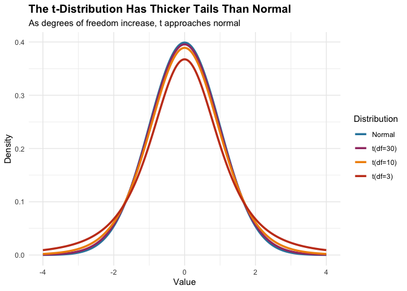

Key points about the t-distribution:

- **Thicker tails** = more probability for extreme values
- **Degrees of freedom (df)** = n - 1 for most applications
- As df increases, t-distribution → normal distribution
- Used for hypothesis testing with small samples (coming soon!)

## Summary

We’ve built the mathematical foundation for statistical inference:

1. **Probability** quantifies uncertainty using numbers from 0 to 1
2. **Discrete distributions** assign probabilities to countable outcomes
3. **Continuous distributions** describe probabilities over ranges
4. The **normal distribution** is central to statistics - symmetric, bell-shaped, and determined by μ and σ
5. **Z-scores** standardize values to “standard deviations from mean”
6. The **empirical rule** gives quick probability estimates (68-95-99.7)
7. R functions (`pnorm`, `qnorm`, `dnorm`) make probability calculations straightforward and are the cumulative distribution function (CDF), quantile function, and probability density function (PDF) for the normal distribution.

This foundation enables us to move from describing what we see in our data to making inferences about populations, testing hypotheses, and quantifying uncertainty. When we combine this what what we have already learned about sampling distributions, we are now ready to start doing statistics.

## Study Questions for Probability and Probability Distributions

### Understanding Probability Concepts

1. What is probability? What values can a probability take, and what do those values mean?
2. When rolling two dice, why is 7 the most likely sum? How many ways can you get a sum of 7 versus a sum of 2?
3. Explain the difference between discrete and continuous probability distributions.
4. Why is the probability of getting exactly 51.7% in a continuous distribution technically 0? What question should we ask instead?

### Parameters vs. Statistics

5. What’s the difference between μ and x̄? Between σ and s? Why do we use different symbols?
6. A pollster surveys 1,000 voters and finds that 52% support a candidate. Is 52% a parameter or a statistic? What about the true support level among all voters?

### The Normal Distribution

7. List three key properties of the normal distribution.
8. What two parameters completely determine a normal distribution? How do changes in each parameter affect the shape?
9. TRUE or FALSE: In a normal distribution, the mean, median, and mode are all equal. Explain why.

### Z-Scores and Standardization

10. If someone’s test score has a z-score of -1.5, what does this tell you about their performance?
11. Convert these values to z-scores:
    - X = 85, μ = 75, σ = 10
    - X = 60, μ = 75, σ = 10
12. If approval ratings are N(45, 8), what z-score corresponds to an approval rating of 53%?

### The Empirical Rule

13. State the empirical rule (68-95-99.7 rule). What assumption must be true for this rule to apply?
14. If test scores follow N(70, 10), use the empirical rule to find approximately:
    - What percentage of students score between 60 and 80?
    - What percentage score above 90?
    - What range contains the middle 95% of scores?

### Working with R Functions

15. Match each R function with what it calculates:
    - `pnorm()`
    - `qnorm()`
    - `dnorm()`
    - `rnorm()`

    A. Generates random values

    B. Finds the height of the curve

    C. Finds the value given a probability

    D. Finds the probability given a value
16. What does `pnorm(100, mean = 100, sd = 15)` return? Explain why without running the code.
17. If `pnorm(30, mean = 25, sd = 5)` returns 0.841, what would `qnorm(0.841, mean = 25, sd = 5)` return? Explain.

### Calculating Probabilities in R

18. Voter turnout in a district is normally distributed with mean 55% and standard deviation 8%. Write R code to find:
    1. The probability that turnout is less than 50%
    2. The probability that turnout is greater than 65%
    3. The probability that turnout is between 50% and 60%
19. For the same distribution (N(55, 8)), write R code to find:
    1. The 90th percentile of turnout
    2. The turnout level that only 5% of elections exceed
    3. The range that contains the middle 80% of turnout values
20. A student runs this code:

`qnorm(0.5, mean = 100, sd = 15)`

Without running it, what value will it return and why?

### Challenge Problems (advanced/optional/not on test)

Challenge 1. Write R code to verify the empirical rule. Generate 10,000 values from N(100, 15), then calculate what percentage fall within 1, 2, and 3 standard deviations of the mean.

Challenge 2. Two districts have voter turnout distributions:

District A: N(60, 5)

District B: N(55, 10)

Which district is more likely to have turnout above 65%? Below 50%? Show your work using R code.